# Tutorial 0

Ryan Huang

7/17/2019

```r
knitr::opts_chunk$set(echo = TRUE)
# install.packages("tidyverse")
library(tidyverse)
library(rstan)
```

## 0.1 Introduction of tidyverse

### 0.1.1 Reference:

Become a master: https://www.datacamp.com/courses/introduction-to-the-tidyverse?tap_a=5644-dce66f&tap_s=194899%E2%80%931fb421&source=post_page

Learning by doing:

1. 輕鬆學習r語言: https://medium.com/datainpoint/r-essentials/home
2. tidyverse style guide: https://style.tidyverse.org/index.html
3. 謝吉隆-R4DS(CH 4): https://docs.google.com/document/d/1e7jd9TAi1hppu0di5yZsDXbwoX2oAJ2O4l6UESVJePU/edit#heading=h.h4fy3dyecxiw
4. 謝吉龍-新聞資料處理與視覺呈現: https://github.com/P4CSS/R1072

### 0.1.2 pipeline operator

ref: https://style.tidyverse.org/pipes.html

The pipeline operator will put the object on its left to the function on its right. *The short key for `%>%` is `shift`+`command`+`M` or `shift`+`ctrl`+`M`

```r
iris
```

| Sepal.Length | Sepal.Width | Petal.Length | Petal.Width | Species |
| --- | --- | --- | --- | --- |
| 5.1 | 3.5 | 1.4 | 0.2 | setosa |
| 4.9 | 3.0 | 1.4 | 0.2 | setosa |
| 4.7 | 3.2 | 1.3 | 0.2 | setosa |
| 4.6 | 3.1 | 1.5 | 0.2 | setosa |
| 5.0 | 3.6 | 1.4 | 0.2 | setosa |
| 5.4 | 3.9 | 1.7 | 0.4 | setosa |
| 4.6 | 3.4 | 1.4 | 0.3 | setosa |
| 5.0 | 3.4 | 1.5 | 0.2 | setosa |
| 4.4 | 2.9 | 1.4 | 0.2 | setosa |
| 4.9 | 3.1 | 1.5 | 0.1 | setosa |

[output cut: 140 more lines]

```r
mean(iris$Sepal.Length)
```

```
## [1] 5.843333
```

```r
iris$Sepal.Length %>% mean()
```

```
## [1] 5.843333
```

```r
lm(Sepal.Length ~ Sepal.Width, data = iris)
```

```
##
## Call:
## lm(formula = Sepal.Length ~ Sepal.Width, data = iris)
##
## Coefficients:
## (Intercept)  Sepal.Width
##      6.5262      -0.2234
```

```r
iris %>% lm(Sepal.Length ~ Sepal.Width, data = .)
```

```
##
## Call:
## lm(formula = Sepal.Length ~ Sepal.Width, data = .)
##
## Coefficients:
## (Intercept)  Sepal.Width
##      6.5262      -0.2234
```

We may want to calculate the mean and var of different species in the data set. In this case, we need to do the following things:

1. `select` the required columns
2. `group` the data by iris species
3. use `summarise` function to get the result

```r
iris %>%
  select(Sepal.Length, Species) %>%
  group_by(Species) %>%
  summarise(mean(Sepal.Length),
            var(Sepal.Length))
```

| Species | mean(Sepal.Length) | var(Sepal.Length) |
| --- | --- | --- |
| setosa | 5.006 | 0.1242490 |
| versicolor | 5.936 | 0.2664327 |
| virginica | 6.588 | 0.4043429 |

Base R

```r
aggregate(iris$Sepal.Length, by = list(iris$Species), FUN=mean)
```

| Group.1 | x |
| --- | --- |
| setosa | 5.006 |
| versicolor | 5.936 |
| virginica | 6.588 |

```r
aggregate(iris$Sepal.Length, by = list(iris$Species), FUN=var)
```

| Group.1 | x |
| --- | --- |
| setosa | 0.1242490 |
| versicolor | 0.2664327 |
| virginica | 0.4043429 |

```r
iris %>%
  select(Sepal.Length, Species) %>%
  group_by(Species) %>%
  summarise(mean(Sepal.Length),
            var(Sepal.Length))
```

| Species | mean(Sepal.Length) | var(Sepal.Length) |
| --- | --- | --- |
| setosa | 5.006 | 0.1242490 |
| versicolor | 5.936 | 0.2664327 |
| virginica | 6.588 | 0.4043429 |

```r
iris %>%
  select(Species, Sepal.Length) %>%
  group_by(Species) %>%
  summarise(mean(Sepal.Length),
            var(Sepal.Length))
```

| Species | mean(Sepal.Length) | var(Sepal.Length) |
| --- | --- | --- |
| setosa | 5.006 | 0.1242490 |
| versicolor | 5.936 | 0.2664327 |
| virginica | 6.588 | 0.4043429 |

Alternative base r style:

```r
aggregate(iris$Sepal.Length, by = list(iris$Species), FUN = mean)
```

| Group.1 | x |
| --- | --- |
| setosa | 5.006 |
| versicolor | 5.936 |
| virginica | 6.588 |

```r
aggregate(iris$Sepal.Length, by = list(iris$Species), FUN = var)
```

| Group.1 | x |
| --- | --- |
| setosa | 0.1242490 |
| versicolor | 0.2664327 |
| virginica | 0.4043429 |

### 0.1.3 Common task done by Tidyverse

ref: https://medium.com/datainpoint/dplyr-%E5%85%AD%E5%80%8B%E5%9F%BA%E6%9C%AC%E8%B3%87%E6%96%99%E8%99%95%E7%90%86%E6%8A%80%E6%B3%95-d6cf16606fd0

Here we will use the `iris` data to demo the following tasks using tidyverse

1. column selection
2. row selection (filtering)
3. create data.frame/tibble
4. add a column

```r
# column selection
iris %>% select(Sepal.Length, Sepal.Width, Species)
```

| Sepal.Length | Sepal.Width | Species |
| --- | --- | --- |
| 5.1 | 3.5 | setosa |
| 4.9 | 3.0 | setosa |
| 4.7 | 3.2 | setosa |
| 4.6 | 3.1 | setosa |
| 5.0 | 3.6 | setosa |
| 5.4 | 3.9 | setosa |
| 4.6 | 3.4 | setosa |
| 5.0 | 3.4 | setosa |
| 4.4 | 2.9 | setosa |
| 4.9 | 3.1 | setosa |

[output cut: 140 more lines]

```r
iris %>% select(-Species)
```

| Sepal.Length | Sepal.Width | Petal.Length | Petal.Width |
| --- | --- | --- | --- |
| 5.1 | 3.5 | 1.4 | 0.2 |
| 4.9 | 3.0 | 1.4 | 0.2 |
| 4.7 | 3.2 | 1.3 | 0.2 |
| 4.6 | 3.1 | 1.5 | 0.2 |
| 5.0 | 3.6 | 1.4 | 0.2 |
| 5.4 | 3.9 | 1.7 | 0.4 |
| 4.6 | 3.4 | 1.4 | 0.3 |
| 5.0 | 3.4 | 1.5 | 0.2 |
| 4.4 | 2.9 | 1.4 | 0.2 |
| 4.9 | 3.1 | 1.5 | 0.1 |

[output cut: 140 more lines]

```r
# row filtering
iris %>% filter(Sepal.Length > 5.87)
```

| Sepal.Length | Sepal.Width | Petal.Length | Petal.Width | Species |
| --- | --- | --- | --- | --- |
| 7.0 | 3.2 | 4.7 | 1.4 | versicolor |
| 6.4 | 3.2 | 4.5 | 1.5 | versicolor |
| 6.9 | 3.1 | 4.9 | 1.5 | versicolor |
| 6.5 | 2.8 | 4.6 | 1.5 | versicolor |
| 6.3 | 3.3 | 4.7 | 1.6 | versicolor |
| 6.6 | 2.9 | 4.6 | 1.3 | versicolor |
| 5.9 | 3.0 | 4.2 | 1.5 | versicolor |
| 6.0 | 2.2 | 4.0 | 1.0 | versicolor |
| 6.1 | 2.9 | 4.7 | 1.4 | versicolor |
| 6.7 | 3.1 | 4.4 | 1.4 | versicolor |

[output cut: 60 more lines]

```r
# create data.frame/tibble
data1 = data.frame(
  a = iris$Sepal.Length,
  b = iris$Sepal.Width,
  c = iris$Petal.Length)

data2 = tibble(
  a = iris$Sepal.Length,
  b = iris$Sepal.Width,
  c = iris$Petal.Length)

data3 = as.data.frame(data2)
data4 = as_tibble(data1)

# add a column: Sepal.Length / Sepal.Width
"$ vs mutate"
```

```
## [1] "$ vs mutate"
```

```r
data4$d = data4$a / data4$b

data5 = tibble(
  a = iris$Sepal.Length,
  b = iris$Sepal.Width,
  c = iris$Petal.Length) %>%
  mutate(d = a / b)
```

### 0.1.4 Apply function family

ref:

1. https://www.guru99.com/r-apply-sapply-tapply.html
2. https://www.r-bloggers.com/r-tutorial-on-the-apply-family-of-functions/
3. https://www.datacamp.com/community/tutorials/r-tutorial-apply-family

`apply` function can be viewed as a substitute to the loop, in r, using apply instead on loop is important for better **efficiency**.

#### 0.1.4.1 Apply family

```r
a = iris %>%
  select(-Species) %>%
  apply(., 1, function(a) a[1]+a[2]+a[3]+a[4])
b = iris %>%
  select(-Species) %>%
  apply(., 1, sum)

tibble(a=a,
       b=b)
```

| a | b |
| --- | --- |
| 10.2 | 10.2 |
| 9.5 | 9.5 |
| 9.4 | 9.4 |
| 9.4 | 9.4 |
| 10.2 | 10.2 |
| 11.4 | 11.4 |
| 9.7 | 9.7 |
| 10.1 | 10.1 |
| 8.9 | 8.9 |
| 9.6 | 9.6 |

[output cut: 140 more lines]

### 0.1.5 Plotting by ggplot2

ref:

1. https://blog.gtwang.org/r/ggplot2-tutorial-layer-by-layer-plotting/
2. https://www.jianshu.com/p/03719d7c207f
3. http://lifesci-murmur.blogspot.com/2017/11/r-ggplot-point-plot-boxplot.html
4. http://lifesci-murmur.blogspot.com/search/label/ggplot

ggplot allows you to draw a plot by layers. plot = data + Aesthetics + geometry

1. create the ggplot object with the data set
2. incrementally add layers

2-1. graph part: geom_xx

2-2. text part: label, title…etc

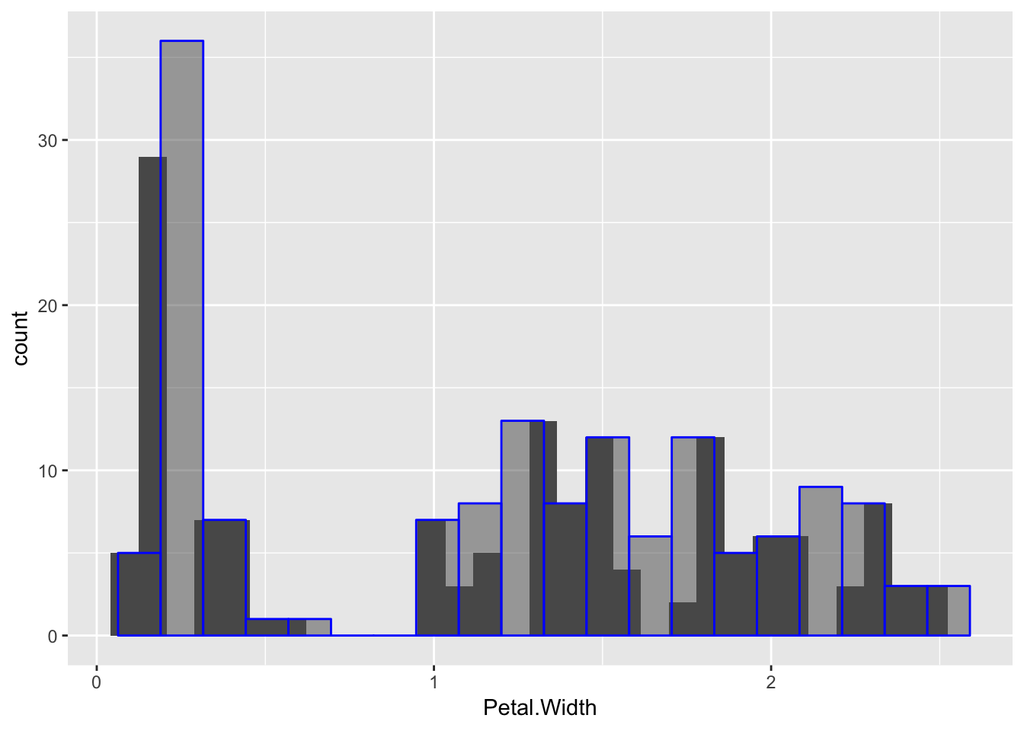

```r
# one dimension: histogram, vline
a = iris %>% ggplot() +
  geom_histogram(aes(Petal.Width), bins = 30) +
  geom_histogram(aes(Petal.Width), bins = 20, colour="blue", alpha=0.5)
a
```

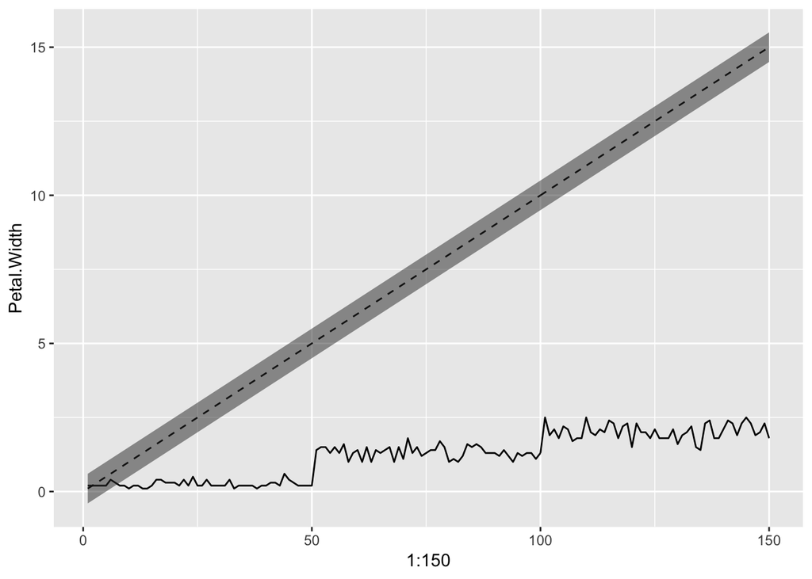

```r
# two dimension: lineplot, areaplot
iris %>% ggplot() +
  geom_line(
    aes(x=1:150, y=Petal.Width)) +
  geom_line(
    aes(x=1:150, y=seq(1,150)/10),
    linetype="dashed") +
  geom_ribbon(
    aes(x    = 1:150,
        ymin = seq(1,150)/10 -.5,
        ymax = seq(1,150)/10 +.5),
    alpha=0.5)
```

#### 0.1.5.1 legend / color

In a 2-D plot like a line plot or a scatter plot, setting the color is like adding one more dimension to the plot. So we need to specify how we want to color the plot by adding one more variable in the aesthetic statement.

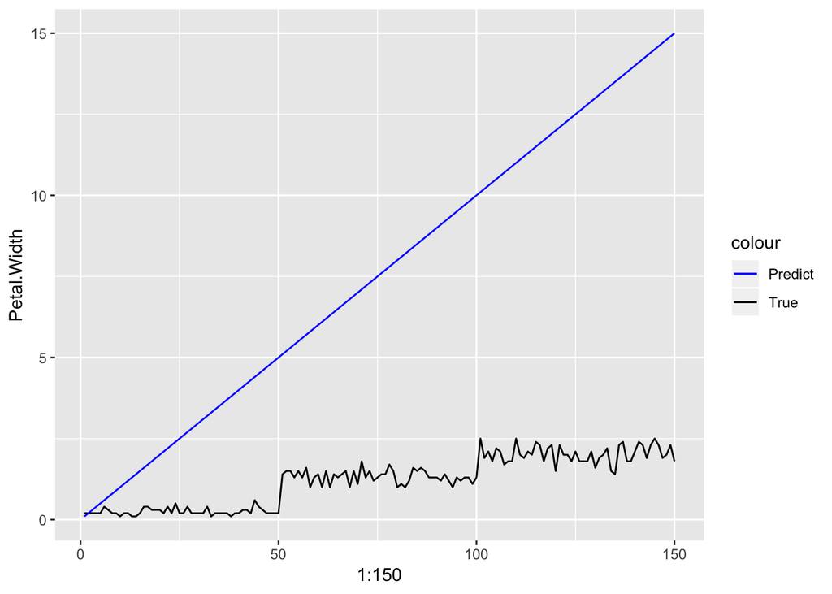

```r
# legend
p = iris %>% ggplot() +
  geom_line(
    aes(x=1:150, y=Petal.Width, color='True')) +
  geom_line(
    aes(x=1:150, y=seq(1,150)/10, color='Predict')) +
  scale_color_manual(values = c("blue", "black"))

p
```

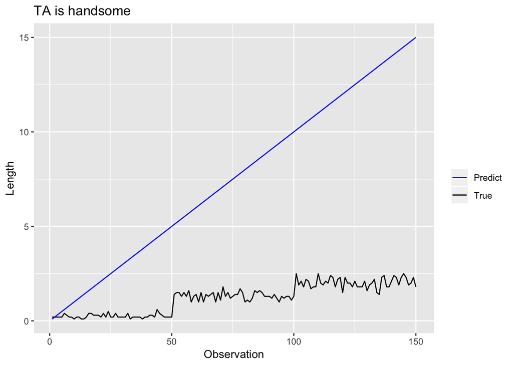

```r
# label / title
p +
  labs(y="Length", x="Observation", color="", title="TA is handsome")
```

## 0.2 Introduction of Stan

### 0.2.1 Reference

Stan User Guide: https://mc-stan.org/docs/2_19/stan-users-guide/index.html Stan lm Tutorial: https://ourcodingclub.github.io/2018/04/17/stan-intro.html Cheat sheet: http://www.sumsar.net/files/posts/2017-bayesian-tutorial-exercises/stan_cheat_sheet2.12.pdf Tutorial: http://mlss2014.hiit.fi/mlss_files/2-stan.pdf

### 0.2.2 Base r vs Stan

In this tutorial, I will focus on the big picture of coding a `Stan` program, in future lectures, you will learn about the details of the model.

Example: `iris` dataset

x = Sepal.Width

y = Sepal.Length

1. Model fitting
2. Prediction

#### 0.2.2.1 Base r: lm()

```r
# Fit lm model
model = iris %>% lm(Sepal.Length ~ Sepal.Width, data = .)

# Prediction
back.test =
  data.frame(
    Sepal.Width = iris$Sepal.Width) %>%
  mutate(
    lm_pred.y = predict(model, .))

back.test
```

| Sepal.Width | lm_pred.y |
| --- | --- |
| 3.5 | 5.744459 |
| 3.0 | 5.856139 |
| 3.2 | 5.811467 |
| 3.1 | 5.833803 |
| 3.6 | 5.722123 |
| 3.9 | 5.655114 |
| 3.4 | 5.766795 |
| 3.4 | 5.766795 |
| 2.9 | 5.878475 |
| 3.1 | 5.833803 |

[output cut: 140 more lines]

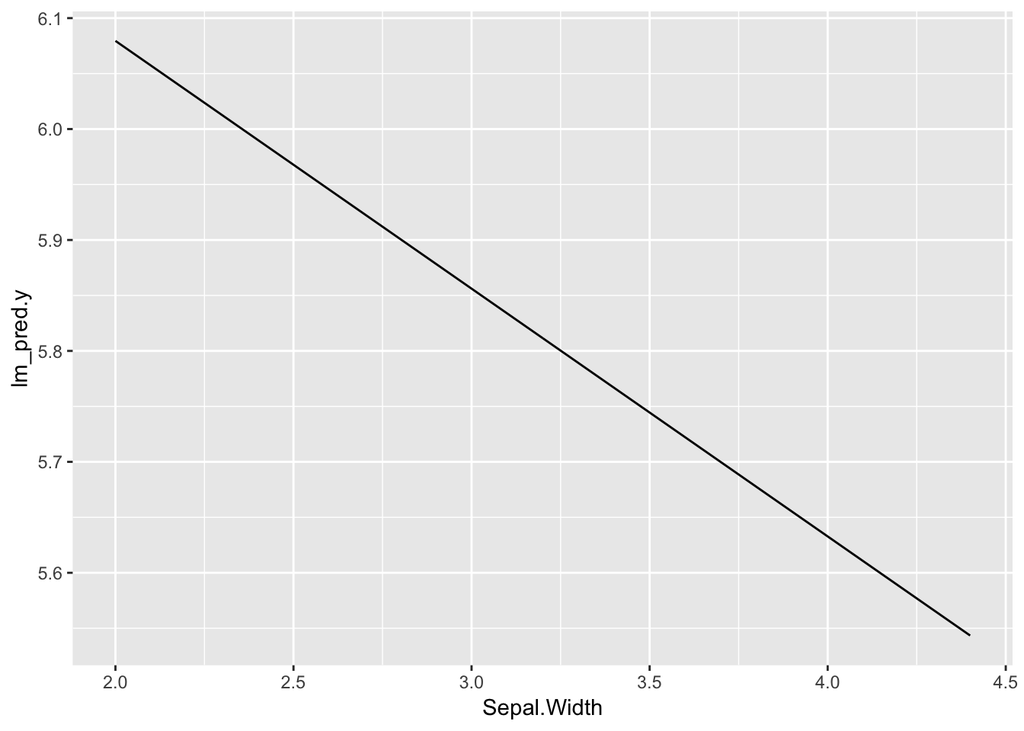

```r
plt1 = back.test %>%
  ggplot() +
  geom_line(aes(Sepal.Width, lm_pred.y))
plt1
```

#### 0.2.2.2 Stan lm

In `Stan`, the process is very similar. 1. Write down the statistical model 2. Fit the data into the model 3. Prediction

```r
lm.model = "
data {
    int N;  // length of data
    vector[N] x;
    vector[N] y;
}
parameters {
    real alpha;
    real beta;
    real<lower=0> sigma;
}
model {
  // prior
    alpha ~ normal(0,5);
    beta ~ normal(0,1);
  sigma ~ normal(0,1);

  //model
    y ~ normal(alpha + x * beta, sigma);
}
generated quantities {
    real pred_y[N];
  pred_y = normal_rng(alpha + beta * x, sigma);
}
"
lm.data = list(
  N = nrow(iris),
  x = iris$Sepal.Width,
  y = iris$Sepal.Length
)
lm.fit = stan(model_code = lm.model, data = lm.data)
lm.fit
```

```
## Inference for Stan model: c98216b46a2d1fae9a41851161202fcd.
## 4 chains, each with iter=2000; warmup=1000; thin=1;
## post-warmup draws per chain=1000, total post-warmup draws=4000.
##
##               mean se_mean   sd   2.5%    25%    50%    75%  97.5% n_eff
## alpha         6.43    0.01 0.50   5.46   6.09   6.44   6.78   7.38  1168
## beta         -0.19    0.00 0.16  -0.50  -0.30  -0.20  -0.08   0.12  1176
## sigma         0.83    0.00 0.05   0.74   0.80   0.83   0.86   0.93  1940
## pred_y[1]     5.74    0.01 0.84   4.13   5.16   5.74   6.30   7.39  3569
## pred_y[2]     5.87    0.01 0.85   4.13   5.32   5.86   6.43   7.51  4060
## pred_y[3]     5.82    0.01 0.84   4.18   5.25   5.83   6.41   7.45  4082
## pred_y[4]     5.84    0.01 0.84   4.17   5.26   5.85   6.39   7.46  3472
## pred_y[5]     5.74    0.01 0.83   4.10   5.19   5.73   6.28   7.41  3907
## pred_y[6]     5.68    0.01 0.85   4.00   5.12   5.68   6.26   7.33  3848
## pred_y[7]     5.77    0.01 0.82   4.19   5.22   5.77   6.31   7.43  3506
## pred_y[8]     5.76    0.01 0.83   4.21   5.20   5.75   6.33   7.42  4159
## pred_y[9]     5.87    0.01 0.85   4.21   5.29   5.85   6.44   7.56  3983
## pred_y[10]    5.82    0.01 0.83   4.17   5.27   5.79   6.36   7.48  3762
## pred_y[11]    5.71    0.01 0.84   4.09   5.13   5.70   6.28   7.36  3876
## pred_y[12]    5.74    0.01 0.84   4.06   5.19   5.74   6.28   7.40  3830
## pred_y[13]    5.85    0.01 0.84   4.22   5.28   5.84   6.41   7.46  4142
## pred_y[14]    5.84    0.01 0.82   4.22   5.30   5.82   6.38   7.49  4040
## pred_y[15]    5.66    0.01 0.85   3.99   5.08   5.66   6.22   7.32  3642
## pred_y[16]    5.56    0.01 0.86   3.91   4.98   5.55   6.14   7.28  3343
## pred_y[17]    5.68    0.01 0.84   4.05   5.11   5.67   6.24   7.33  3650
## pred_y[18]    5.76    0.01 0.83   4.18   5.18   5.75   6.31   7.40  3978
## pred_y[19]    5.72    0.01 0.86   4.00   5.15   5.70   6.29   7.41  3683
## pred_y[20]    5.72    0.01 0.85   4.06   5.15   5.73   6.29   7.39  3901
## pred_y[21]    5.79    0.01 0.84   4.14   5.23   5.78   6.34   7.46  3920
## pred_y[22]    5.71    0.01 0.84   4.04   5.16   5.74   6.28   7.37  3631
## pred_y[23]    5.76    0.01 0.83   4.14   5.22   5.75   6.30   7.39  4221
## pred_y[24]    5.81    0.01 0.83   4.15   5.25   5.82   6.37   7.47  4117
## pred_y[25]    5.77    0.01 0.83   4.14   5.21   5.78   6.31   7.38  3585
## pred_y[26]    5.85    0.01 0.85   4.19   5.27   5.83   6.41   7.52  3796
## pred_y[27]    5.76    0.01 0.83   4.14   5.21   5.74   6.31   7.42  4055
## pred_y[28]    5.75    0.01 0.84   4.09   5.19   5.77   6.32   7.38  4022
## pred_y[29]    5.77    0.01 0.85   4.05   5.21   5.76   6.34   7.43  3954
## pred_y[30]    5.81    0.01 0.84   4.16   5.23   5.82   6.37   7.46  4109
## pred_y[31]    5.86    0.01 0.84   4.23   5.28   5.84   6.42   7.53  3856
## pred_y[32]    5.78    0.01 0.83   4.15   5.22   5.77   6.34   7.40  3704
```

[output cut: 264 more lines]

```
## pred_y[142]    1
## pred_y[143]    1
## pred_y[144]    1
## pred_y[145]    1
## pred_y[146]    1
## pred_y[147]    1
## pred_y[148]    1
## pred_y[149]    1
## pred_y[150]    1
## lp__           1
##
## Samples were drawn using NUTS(diag_e) at Mon Aug 12 19:48:41 2019.
## For each parameter, n_eff is a crude measure of effective sample size,
## and Rhat is the potential scale reduction factor on split chains (at
## convergence, Rhat=1).
```

```r
model
```

```
##
## Call:
## lm(formula = Sepal.Length ~ Sepal.Width, data = .)
##
## Coefficients:
## (Intercept)  Sepal.Width
##      6.5262      -0.2234
```

#### 0.2.2.3 Stan syntax

In the regression example, you way notice something strange:

1. `y` ~ `normal()` vs. `pred_y` = `normal_rng()`
2. vector[N] y vs. real pred_y[N]
3. `mu` in both `model` and `generated quantities`
4. `y` ~ `normal()` vs. `pred` = `normal_rng()`

```r
"model {
  mu = alpha + beta * x;
  y ~ normal(mu, sigma);
}"
```

```
## [1] "model {\n  mu = alpha + beta * x;\n  y ~ normal(mu, sigma);\n}"
```

```r
"generated quantities {
  real pred_y[N];
  mu = alpha + beta * x;
  pred_y = normal_rng(mu, sigma);
}
"
```

```
## [1] "generated quantities {\n  real pred_y[N];\n  mu = alpha + beta * x;\n  pred_y = normal_rng(mu, sigma);\n}\n"
```

2. vector[N] y vs. real pred_y[N]

`vector[N] y` is a vector, which supports linear algebra calculation.

`real pred_y[N]` is an array of reals.

rng_function: https://mc-stan.org/docs/2_18/functions-reference/vectorization.html#prng-vectorization vector vs. array: https://mc-stan.org/docs/2_19/stan-users-guide/basic-motivation.html

```r
# x: vector
# y: vector

"model {
  mu = alpha + beta * x;
  y ~ normal(mu, sigma);
}"
```

```
## [1] "model {\n  mu = alpha + beta * x;\n  y ~ normal(mu, sigma);\n}"
```

```r
"generated quantities {
  real pred_y[N];
  mu = alpha + beta * x;
  pred_y = normal_rng(mu, sigma);

  vector[N] pred_y;
  for (1:N){
    mu = alpha + beta * x[i];
    pred_y[i] = normal_rng(mu, sigma);
  }
}
"
```

```
## [1] "generated quantities {\n  real pred_y[N];\n  mu = alpha + beta * x;\n  pred_y = normal_rng(mu, sigma);\n\n  vector[N] pred_y;\n  for (1:N){\n    mu = alpha + beta * x[i];\n    pred_y[i] = normal_rng(mu, sigma);\n  }\n}\n"
```

3. `mu` in both `model` and `generated quantities`

In each block, the variables have different scope. Variables declared in model block are local variables and can’t be used directly in other blocks.

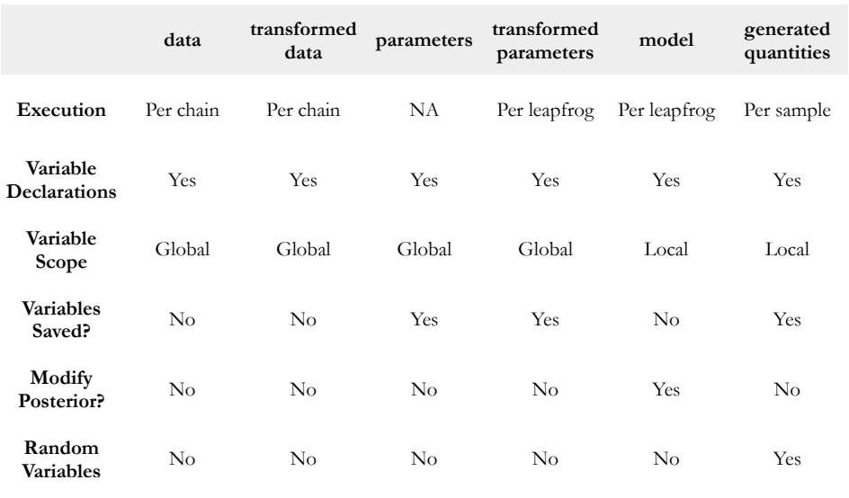